# Intersection COVID-19: Italy

2020-04-01 18:16:33

# Objective

Investigate the relation (if any) between influenza vaccination coverage and measures related to COVID-19 epidemic in Italy. Demigrafical and health related data of each italian region are also taken into account.

# Italy

## Influenza Vaccination Coverage

Data of the influenza vaccination coverage in Italy can be found in the web site of [“Ministero della Salute”](http://www.salute.gov.it/imgs/C_17_tavole_19_allegati_iitemAllegati_0_fileAllegati_itemFile_3_file.pdf). Data are from 1999‐2000 to 2018‐2019. So… pretty cool.

Data of the general population are in a `pdf` table in page 1. We can use `{tabulizer}` to get them. **Last data are 07-15-2019**

```r
library(DT)
library(Hmisc)
library(rvest)
library(htmltools)
library(htmlwidgets)
library(janitor)
library(lubridate)
library(lemon)
library(miniUI)
library(plotly)
library(scales)
library(tabulizer) # this library require specific version of Java and can be a pain to install
library(tidyverse)
library(xml2)
library(vroom)

web_page <- "http://www.salute.gov.it/imgs/C_17_tavole_19_allegati_iitemAllegati_0_fileAllegati_itemFile_3_file.pdf"

area_sel <- c(
  top = 92.6606873324687, left = 49.819066386841, bottom = 436.401946791649,
  right = 772.17388698945
) # got this using locate_areas()

suppressWarnings(
  fl_tab <- extract_tables(
    web_page,
    output = "data.frame",
    pages = 1,
    area =  list(area_sel),
    guess = FALSE
  )[[1]]
)

# inFLuenza coverage ITaly

fl_it <- fl_tab %>%
  rename(region = X) %>%
  {
    x <- .
    x <- x[3:nrow(x), ]
    names(x) <- str_remove_all(names(x), "[[:punct:]]|X")
    x
  } %>%
  mutate_all(list(~ gsub(., pattern = ",", replacement = "."))) %>%
  rename("2019" = ncol(.)) %>%
  {
    x <- .
    x[x == ""] <- NA
    x$region[x$region == "P. A. Trento"] <- "P.A. Trento"
    x <- x[!is.na(x$region), ]
    x
  }


# fl_it
```

Let’s plot

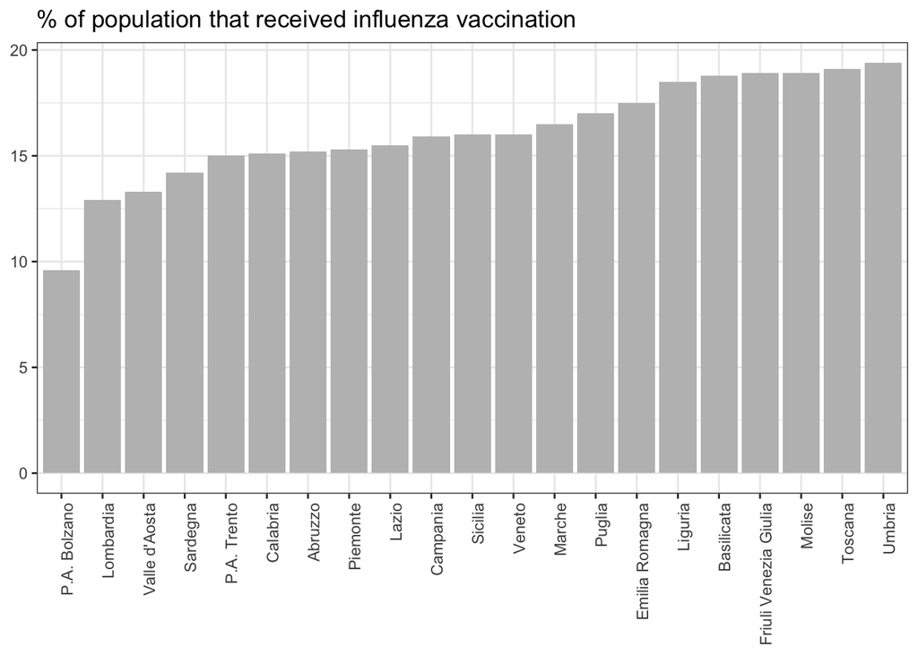

```r
fl_it_2019 <- fl_it %>%
  rename(perc_imm = "2019") %>%
  mutate(perc_imm = as.numeric(perc_imm)) %>%
  select(region, perc_imm)

fl_it_2019 %>%
  ggplot(aes(reorder(region, perc_imm), perc_imm)) +
  geom_col(fill = "grey") +
  theme_bw() +
  theme(axis.text.x = element_text(angle = 90, hjust = 1)) +
  labs(x = NULL, y = NULL, title = "% of population that received influenza vaccination")
```

We actually have influenza vaccination coverage for people that are 65 > It is in the same file but at page 3

```r
area_sel2 <- c(
  top = 75.63785, left = 51.12191, bottom = 434.73870 ,
  right =   795.57018
) # got this using locate_areas()



suppressWarnings(
  fl65_tab <- extract_tables(
    web_page,
    output = "data.frame",
    pages = 3,
    area =  list(area_sel2),
    guess = FALSE
  )[[1]]
)

# inFLuenza coverage ITaly

fl65_it <- fl65_tab %>%
  rename(region = X) %>%
  {
    x <- .
    x <- x[3:nrow(x), ]
    names(x) <- str_remove_all(names(x), "[[:punct:]]|X")
    x
  } %>%
  mutate_all(list(~ gsub(., pattern = ",", replacement = "."))) %>%
  rename("2019" = ncol(.)) %>%
  {
    x <- .
    x[x == ""] <- NA
    x$region[x$region == "P. A. Trento"] <- "P.A. Trento"
    x <- x[!is.na(x$region), ]
    x
  }

fl65_it_2019 <- fl65_it %>%
  rename(perc_imm65 = "2019") %>%
  mutate(perc_imm65 = as.numeric(perc_imm65)) %>%
  select(region, perc_imm65)
```

Let’s put it together with the other flu data

```r
fl_it_2019 <- inner_join(fl65_it_2019, fl_it_2019, by = "region")
```

## Demographics

Istat maintains a database of a variety of statistical indicators accessible from its [website](http://dati.istat.it/). Info on the age of the population can be found going to `Popolazione famiglie` > `Popolazione resident al 1 gennaio` > `Per fascia d'eta`.

Details about the dataset can be found [here](http://siqual.istat.it/SIQual/visualizza.do?id=0019900&refresh=true&language=IT)

Let’s check the demographic.

```r
dem_it_p <- vroom(
  "data/italy/pop_it.csv",
  col_types = cols(
    ITTER107 = col_character(),
    Territorio = col_character(),
    TIPO_DATO15 = col_character(),
    `Tipo di indicatore demografico` = col_character(),
    SEXISTAT1 = col_double(),
    Sesso = col_character(),
    ETA1 = col_character(),
    Età  = col_character(),
    STATCIV2 = col_double(),
    `Stato civile` = col_character(),
    TIME = col_double(),
    `Seleziona periodo` = col_double(),
    Value = col_double(),
    `Flag Codes` = col_character(),
    Flags = col_character()
  )
) %>%
  rename(
    region = Territorio,
    index = `Tipo di indicatore demografico`,
    sex = Sesso,
    age = `Età`,
    marital_status = `Stato civile`,
    year = `Seleziona periodo`,
    value = Value
  ) %>%
  select(region, index, sex, age, marital_status, year, value) %>%
  filter(age != "totale", sex != "totale", marital_status == "totale") %>%
  mutate(
    age = as.numeric(str_remove_all(age, "[[:alpha:]]")),
    sex = recode(sex, femmine = "female", maschi = "male")
  )

dem_it_p$region <- recode(
  dem_it_p$region,
  "Valle d'Aosta / Vallée d'Aoste" = "Valle d'Aosta",
  "Provincia Autonoma Bolzano / Bozen" = "P.A. Bolzano",
  "Provincia Autonoma Trento"  = "P.A. Trento",
  "Friuli-Venezia Giulia"  = "Friuli Venezia Giulia",
  "Emilia-Romagna" = "Emilia Romagna"
)
```

These data have `Trentino Alto Adige / Südtirol` but also `PA Trento` and `PA Bolazono`. Let’s see if `Trentino Alto Adige` is the sum of the 2.

```r
dem_it_p %>%
  filter(region %in% list("P.A. Bolzano", "P.A. Trento", "Trentino Alto Adige / Südtirol")) %>%
  group_by(region) %>%
  summarize(tot = sum(value))
```

| region | tot |
| --- | --- |
| P.A. Bolzano | 531178 |
| P.A. Trento | 541098 |
| Trentino Alto Adige / Südtirol | 1072276 |

Yes, it is, we need to remove it. Let’s do that and compute some percentage.

```r
dem_it_p <- dem_it_p %>%
  filter(region != "Trentino Alto Adige / Südtirol") %>%
  group_by(region) %>%
  mutate(tot = sum(value)) %>% # this makes total for regions
  ungroup() %>%
  mutate(perc_pop = value / tot * 100)
```

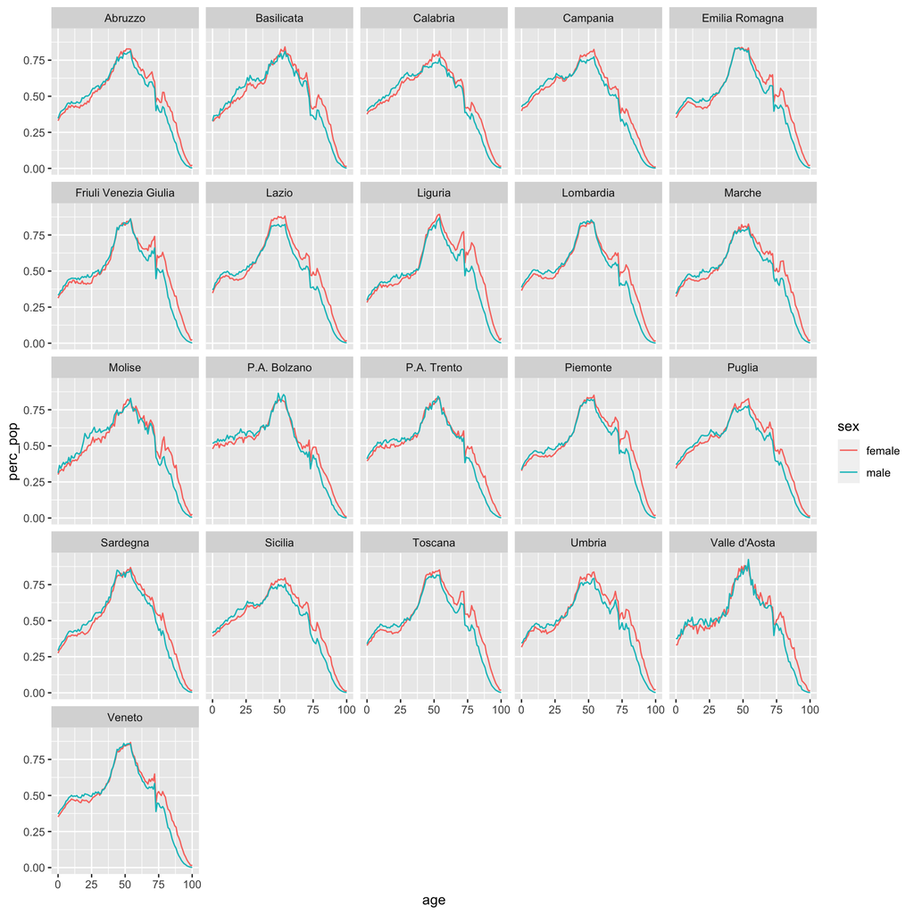

```r
dem_it_p %>%
  ggplot(aes(age, perc_pop, group = sex, color = sex)) +
  geom_line() +
  facet_wrap(~region)
```

The Istituto Superiore Sanità (HHS) provides info regarding the mortality in different age groups fro patients positive for COVID-19 ([link](https://www.epicentro.iss.it/coronavirus/sars-cov-2-decessi-italia)). In an [initial report](https://www.epicentro.iss.it/coronavirus/sars-cov-2-decessi-italia) the age variable was in bin of 10 years (0-9, 10-19..), left closed and right closed; ages more than 90 were binned together.

If we want to consider some variables with modeling packages, we might need a wider format. Let’s get that too.

```r
dem_it_p <- dem_it_p %>%
  mutate(age_bins = cut(age, seq(0, 100, 10), right = FALSE, include.lowest = TRUE)) %>%
  mutate(age_bins = recode(age_bins, "[90,100]" = "[90,100+]")) %>%
  group_by_at(vars(-age, -value, -marital_status, -index, -year, -perc_pop)) %>%
  summarize(value = sum(value), perc_pop = sum(perc_pop)) %>%
  ungroup()


# if we want to use caret or any package for regression we need to have a variable age-sex bins as columns
dem_it_wider <- dem_it_p %>%
  mutate(sex_age_bin = paste0("perc_", sex, "_", age_bins)) %>% # now that we have the perc we create the new factor
  select(region, tot, perc_pop, sex_age_bin) %>%
  # now we do the magic
  pivot_wider(names_from = sex_age_bin, values_from = perc_pop) %>%
  rename(pop_tot = tot)


glimpse(dem_it_p)
```

```
## Observations: 420
## Variables: 6
## $ region   <chr> "Abruzzo", "Abruzzo", "Abruzzo", "Abruzzo", "Abruzzo", "Abru…
## $ sex      <chr> "female", "female", "female", "female", "female", "female", …
## $ tot      <dbl> 1311580, 1311580, 1311580, 1311580, 1311580, 1311580, 131158…
## $ age_bins <fct> "[0,10)", "[10,20)", "[20,30)", "[30,40)", "[40,50)", "[50,6…
## $ value    <dbl> 50838, 56437, 64594, 77139, 98644, 103876, 86974, 69296, 498…
## $ perc_pop <dbl> 3.8760884, 4.3029781, 4.9248997, 5.8813797, 7.5210052, 7.919…
```

Let’s check if the percentage adds up to 100

```r
apply(dem_it_wider[, 3:ncol(dem_it_wider)], 1, sum)
```

```
##  [1] 100 100 100 100 100 100 100 100 100 100 100 100 100 100 100 100 100 100 100
## [20] 100 100
```

We have the demographic data.

**We might want to add the population for square kilometer.**

We can get that from wikipedia.

```r
wiki <- xml2::read_html("https://it.wikipedia.org/wiki/Regioni_d%27Italia")


regions_area_p <- wiki %>%
  rvest::html_nodes("table") %>%
  rvest::html_table(fill = TRUE) %>%
  {
    x <- .
    x[[3]]
  }

# let's clean the names
regions_area <- regions_area_p %>%
  select(Regione, `Superficie (km²)`) %>%
  rename(region = Regione, area_km2 = `Superficie (km²)`) %>%
  mutate(region = str_replace(region, "-", " "), area_km2 = as.numeric(str_remove(area_km2, "[[:blank:]]"))) %>%
  filter(!region %in% c("Trentino Alto Adige", "Italia"))

#  we add those missing regions
regions_area <- bind_rows(regions_area, tribble(
  ~region, ~area_km2,
  "P.A. Bolzano", 7398,
  "P.A. Trento", 2397
))
```

## Health

### Chronic Conditions

On the Istat [website](http://dati.istat.it/) in `Salute e Sanità` > `Stato di salute e consumo di farmaci` > `Stato di Salute in regioni e comuni`. Details on the datasets can be found [here](http://siqual.istat.it/SIQual/visualizza.do?id=0058000&refresh=true&language=IT)

Data are of **2018**

```r
chronic_it_p <- vroom("data/italy/chronic_conditions.csv",
  col_types = cols(
    ITTER107 = col_character(),
    Territorio = col_character(),
    TIPO_DATO_AVQ = col_character(),
    `Tipo dato` = col_character(),
    MISURA_AVQ = col_character(),
    Misura = col_character(),
    TIME = col_double(),
    `Seleziona periodo` = col_double(),
    Value = col_double(),
    `Flag Codes` = col_logical(),
    Flags = col_logical()
  )
) %>%
  clean_names() %>%
  filter(misura == "valori in migliaia") %>% # we keep the absolute values
  mutate(value = value * 1000) # values are in thousands


# we do some cleaning and translations
chronic_it <- chronic_it_p %>%
  rename(region = territorio, ch_condition = tipo_dato_avq) %>%
  mutate(region = str_replace(region, "-", " ")) %>%
  filter(!region %in% c("Trentino Alto Adige / Südtirol", "Italia")) %>%
  # make name consistent
  mutate(region = recode(region,
    "Valle d'Aosta / Vallée d'Aoste" = "Valle d'Aosta",
    "Provincia Autonoma Bolzano / Bozen" =  "P.A. Bolzano",
    "Provincia Autonoma Trento"   =  "P.A. Trento",
    "Fiuli Venezia Giulia"  = "Friuli Venezia Giulia"
  )) %>%
  select(region, ch_condition, value) %>%
  mutate(ch_condition = tolower(str_remove(ch_condition, "0_"))) %>%
  # we make it wilder
  pivot_wider(names_from = ch_condition, values_from = value) %>%
  rename(chronic_aleast_2cron = aleast_2cron, chronic_aleast_1cron = aleast_1cron, chronic_good_h = good_h)
```

### Cigarette Smoking

On the Istat [website](http://dati.istat.it/) in `Salute e Sanità` > `Stili di vita e fattori di rischio` > `Abitudini al fumo`, `Regioni`. Details on the datasets can be found [here](http://siqual.istat.it/SIQual/visualizza.do?id=0058000&refresh=true&language=IT).

**14 years old or more**

```r
smoking_it <- vroom("data/italy/smoking.csv",
  col_types = cols(
    ITTER107 = col_character(),
    Territorio = col_character(),
    TIPO_DATO_AVQ = col_character(),
    `Tipo dato` = col_character(),
    MISURA_AVQ = col_character(),
    Misura = col_character(),
    TIME = col_double(),
    `Seleziona periodo` = col_double(),
    Value = col_double(),
    `Flag Codes` = col_logical(),
    Flags = col_logical()
  )
) %>%
  rename(
    region = Territorio,
    smoking_status = TIPO_DATO_AVQ,
    value = Value
  ) %>%
  filter(Misura == "valori in migliaia") %>%
  select(region, smoking_status, value) %>%
  mutate(region = str_replace(region, "-", " ")) %>%
  filter(!region %in% c("Trentino Alto Adige / Südtirol", "Italia")) %>%
  # make name consistent
  mutate(region = recode(region,
    "Valle d'Aosta / Vallée d'Aoste" = "Valle d'Aosta",
    "Provincia Autonoma Bolzano / Bozen" =  "P.A. Bolzano",
    "Provincia Autonoma Trento"   =  "P.A. Trento",
    "Fiuli Venezia Giulia"  = "Friuli Venezia Giulia"
  )) %>%
  mutate(smoking_status = recode(smoking_status,
    "14_FUMO_SI" = "smoking_current",
    "14_FUMO_EX" = "smoking_ex",
    "14_FUMO_NO" = "smoking_no"
  )) %>%
  filter(smoking_status %in% c("smoking_current", "smoking_ex", "smoking_no")) %>%
  # values are in thousands
  mutate(value = value * 1000) %>%
  pivot_wider(names_from = smoking_status, values_from = value)
```

### Obesity

On the Istat [website](http://dati.istat.it/) in `Salute e Sanità` > `Stili di vita e fattori di rischio` > `Indici di Massa Corporea`, `Regioni`. Details on the datasets can be found [here](http://siqual.istat.it/SIQual/visualizza.do?id=0058000&refresh=true&language=IT).

**18 years old or more**

```r
bweight_it <- vroom("data/italy/bweight_it.csv", col_types = cols(
  ITTER107 = col_character(),
  Territorio = col_character(),
  TIPO_DATO_AVQ = col_character(),
  `Tipo dato` = col_character(),
  MISURA_AVQ = col_character(),
  Misura = col_character(),
  SEXISTAT1 = col_double(),
  Sesso = col_character(),
  TIME = col_double(),
  `Seleziona periodo` = col_double(),
  Value = col_double(),
  `Flag Codes` = col_logical(),
  Flags = col_logical()
)) %>%
  filter(TIME == 2018) %>%
  rename(
    region = Territorio,
    bweight_status = TIPO_DATO_AVQ,
    value = Value,
    ses = Sesso
  ) %>%
  filter(Misura == "valori in migliaia") %>%
  select(region, bweight_status, value) %>%
  mutate(region = str_replace(region, "-", " ")) %>%
  filter(!region %in% c("Trentino Alto Adige / Südtirol", "Italia")) %>%
  # make name consistent
  mutate(region = recode(region,
    "Valle d'Aosta / Vallée d'Aoste" = "Valle d'Aosta",
    "Provincia Autonoma Bolzano / Bozen" =  "P.A. Bolzano",
    "Provincia Autonoma Trento"   =  "P.A. Trento",
    "Fiuli Venezia Giulia"  = "Friuli Venezia Giulia"
  )) %>%
  mutate(bweight_status = recode(bweight_status,
    "18_BMI_SOTTO" = "bweight_under",
    "18_BMI_NORMO" = "bweight_normal",
    "18_BMI_SOVRA" = "bweight_over",
    "18_BMI_OBE" = "bweight_obese"
  )) %>%
  filter(bweight_status %in% c("bweight_under", "bweight_normal", "bweight_over", "bweight_obese")) %>%
  # values are in thousands
  mutate(value = value * 1000) %>%
  pivot_wider(names_from = bweight_status, values_from = value)
```

### Cancer

Data on tumor prevalence (year: ##2016##) can be found in the website of Istituto Superiore Sanità [tumors](http://www.registri-tumori.it/PDF/AIOM2016/I_numeri_del_cancro_2016.pdf). Tab is at pag 35.

** year was 2016 **

```r
web_page <- "http://www.registri-tumori.it/PDF/AIOM2016/I_numeri_del_cancro_2016.pdf"

area_sel <- c(
  top = 240.95886, left = 27.75322, bottom = 534.19809,
  right = 436.61248
) # got this using locate_areas()

suppressWarnings(
  cancer_tab <- extract_tables(
    web_page,
    output = "data.frame",
    pages = 35,
    area =  list(area_sel),
    guess = FALSE
  )[[1]]
  %>%
    na.omit()
)

names(cancer_tab) <-
  c(
    "region",
    paste("cancer",
      c(
        "all",
        "breast",
        "colon",
        "prostate",
        "bladder",
        "lymphoma",
        "head_neck",
        "uterus",
        "lung"
      ),
      sep = "_"
    )
  )

# clean names
cancer_it <- cancer_tab %>%
  mutate(region = recode(region,
    "Trentino Alto" = "Trentino Alto Adige",
    "Emilia" = "Emilia Romagna",
    "Friuli Venezia" = "Friuli Venezia Giulia",
    "Valle D’Aosta" = "Valle d'Aosta"
  )) %>%
  filter(region != "Trentino Alto Adige") %>%
  # in italy . used as , in numbers
  mutate_if(is.double, ~ . * 1000)

# no data on those  but we want to include them anyway for the join

cancer_it[20, "region"] <- "P.A. Bolzano"
cancer_it[21, "region"] <- "P.A. Trento"
```

## COVID-19 Cases

Data of COVID-19 cases and many more info can be found on the website of “protezione civile” (here).

```r
get_cases_italy <- function() {
  dat <- vroom(
    file = "https://raw.githubusercontent.com/pcm-dpc/COVID-19/master/dati-regioni/dpc-covid19-ita-regioni.csv",
    col_types = cols(
      data = col_datetime(format = ""),
      stato = col_character(),
      codice_regione = col_double(),
      denominazione_regione = col_character(),
      lat = col_double(),
      long = col_double(),
      ricoverati_con_sintomi = col_double(),
      terapia_intensiva = col_double(),
      totale_ospedalizzati = col_double(),
      isolamento_domiciliare = col_double(),
      totale_positivi = col_double(),
      variazione_totale_positivi = col_double(),
      nuovi_positivi = col_double(),
      dimessi_guariti = col_double(),
      deceduti = col_double(),
      totale_casi = col_double(),
      tamponi = col_double(),
      note_it = col_character(),
      note_en = col_character()
    )
  ) %>%
    rename(region = denominazione_regione) %>%
    mutate(region = str_replace(region, "-", " ")) %>%
    select(-totale_positivi, -variazione_totale_positivi, -nuovi_positivi, -dimessi_guariti) %>%
      rename(
    date = data,
    state = stato,
    region_cod = codice_regione,
    hospitalized_with_symptoms = ricoverati_con_sintomi,
    intensive_care_unit = terapia_intensiva,
    total_hospitalized = totale_ospedalizzati,
    home_quarantine = isolamento_domiciliare,
    deaths = deceduti,
    tests = tamponi,
    total_cases = totale_casi
  ) %>%
  # select(!c("totale_attualmente_positivi", "nuovi_attualmente_positivi" )) %>%
  mutate(
    cmr = deaths / total_cases * 100,
    chr = total_hospitalized / total_cases * 100,
    cir = intensive_care_unit / total_cases * 100
  ) %>%
  pivot_longer(cols = c("cmr", "chr", "cir", "hospitalized_with_symptoms", "intensive_care_unit", "total_hospitalized", "home_quarantine", "deaths", "total_cases", "tests"), names_to = "COVID19_var", values_to = "value")

  dat
}
```

## Join togheter and correlate

Let’s put together the datasets of influenza coverage and the all the others.

```r
cmr_it <- get_cases_italy()
```

With this we check that the regions are the same across datasets. They are not always very consistent with names.

```r
# check that the names are right otherwise when we join we loose data
lapply(list(
  cmr_it,
  dem_it_wider,
  regions_area,
  chronic_it,
  cancer_it,
  smoking_it,
  bweight_it
), function(x) {
  setdiff(unique(x$region), unique(dem_it_wider$region))
})
```

```
## [[1]]
## character(0)
##
## [[2]]
## character(0)
##
## [[3]]
## character(0)
##
## [[4]]
## character(0)
##
## [[5]]
## character(0)
##
## [[6]]
## character(0)
##
## [[7]]
## character(0)
```

```r
# nuovi attualmente positivi not reliable...look at critiques in recent Italian news
# Join fl with cmr
fl_cmr_it <- inner_join(cmr_it, fl_it_2019, by = "region") %>%
  mutate_at(vars("perc_imm65","perc_imm"), as.numeric)

# join  with demographics
fl_cmr_dem_it <- inner_join(fl_cmr_it, dem_it_wider, by = "region")

# adding regions km2
fl_cmr_dem_it <- inner_join(fl_cmr_dem_it, regions_area, by = "region") %>%
  mutate(pop_km2 = pop_tot / area_km2) %>%
  # reorder col
  select(c(
    "date", "state", "region_cod", "region", "lat", "long", "note_it", "note_en",
    "perc_imm", "perc_imm65", "COVID19_var", "value", "pop_tot", "area_km2", "pop_km2", "perc_female_[0,10)",
    "perc_female_[10,20)", "perc_female_[20,30)", "perc_female_[30,40)",
    "perc_female_[40,50)", "perc_female_[50,60)", "perc_female_[60,70)",
    "perc_female_[70,80)", "perc_female_[80,90)", "perc_female_[90,100+]",
    "perc_male_[0,10)", "perc_male_[10,20)", "perc_male_[20,30)",
    "perc_male_[30,40)", "perc_male_[40,50)", "perc_male_[50,60)",
    "perc_male_[60,70)", "perc_male_[70,80)", "perc_male_[80,90)",
    "perc_male_[90,100+]"
  ))

# join health data
fl_cmr_dem_chronic_it <- inner_join(fl_cmr_dem_it, chronic_it, by = "region")

# join cancer data
fl_cmr_dem_health_cancer_it <- inner_join(fl_cmr_dem_chronic_it, cancer_it, by = "region")

# join smoking data
fl_cmr_dem_health_cancer_smoking_it <- inner_join(fl_cmr_dem_health_cancer_it, smoking_it, by = "region")

# join bweight
fl_cmr_dem_health_cancer_smoking_bweight_it <- inner_join(fl_cmr_dem_health_cancer_smoking_it, bweight_it, by = "region")


all_dat <- fl_cmr_dem_health_cancer_smoking_bweight_it

# make cancer and health as percentage
all_dat <- all_dat %>%
  mutate_at(vars(chronic_osteo:bweight_obese), list(~ (. / pop_tot * 100)))


# all data are as percentage so we remove the perc_ from names
names(all_dat) <- str_remove(names(all_dat), "perc_")
names(all_dat)
```

```
##  [1] "date"                 "state"                "region_cod"
##  [4] "region"               "lat"                  "long"
##  [7] "note_it"              "note_en"              "imm"
## [10] "imm65"                "COVID19_var"          "value"
## [13] "pop_tot"              "area_km2"             "pop_km2"
## [16] "female_[0,10)"        "female_[10,20)"       "female_[20,30)"
## [19] "female_[30,40)"       "female_[40,50)"       "female_[50,60)"
## [22] "female_[60,70)"       "female_[70,80)"       "female_[80,90)"
## [25] "female_[90,100+]"     "male_[0,10)"          "male_[10,20)"
## [28] "male_[20,30)"         "male_[30,40)"         "male_[40,50)"
## [31] "male_[50,60)"         "male_[60,70)"         "male_[70,80)"
## [34] "male_[80,90)"         "male_[90,100+]"       "chronic_osteo"
## [37] "chronic_gastr"        "chronic_heart"        "chronic_aleast_2cron"
## [40] "chronic_hyp"          "chronic_arth"         "chronic_aleast_1cron"
## [43] "chronic_bronc"        "chronic_nervous"      "chronic_diab"
## [46] "chronic_gh"           "chronic_good_h"       "chronic_aller"
## [49] "cancer_all"           "cancer_breast"        "cancer_colon"
## [52] "cancer_prostate"      "cancer_bladder"       "cancer_lymphoma"
## [55] "cancer_head_neck"     "cancer_uterus"        "cancer_lung"
## [58] "smoking_current"      "smoking_ex"           "smoking_no"
## [61] "bweight_under"        "bweight_normal"       "bweight_over"
## [64] "bweight_obese"
```

Now we have our datasets ready for being analyzed…what we need to do is just filter for the `COVID19_var` and date of interest and then run the stats.

# TO DO:

1. flu vaccination coverage by province? **Not available in the public domanin**
2. demographic rural vs city: not found but we have something else
- other: In dati istat `Condizioni Economiche delle famiglie e diseguaglianze` > `Condizioni abitative` > `Affolamento nelle abitazioni`. **We have number of people for square meter. Not a lot of variance though.
- Number of foreigners.
- How active are people. Aspetti della vita quotidiana : Spettacoli - regioni e tipo di comune
- People commuting for work or school
3. data before lock-down look at that dataset with this info.